# Draft Report: D Conduit Statistical Overview

Seth W. Bassett, GISP

September 20, 2015

# 1 General Introduction

The Falmouth 2D-ACM meters, aka the FGS deep sensor network, were originally installed 2003 and mark the genesis of the Florida Geological Survey’s Woodville Karst Plain Instrumentation Project (the history of this project [is documented here](https://github.com/FloridaGeologicalSurvey/KORI/wiki/Project-History)). These meters have been installed at approximately 300 feet below the surface of the water table, in a variety of karst conduits that are responsible for supplying Wakulla Spring with water.

The 2D-ACM units utilized by the FGS in the deep sensor network are manufactured by [Falmouth Scientific, Inc.](http://www.falmouth.com/) of Cataumet, Massachusetts. They were installed in the conduit network by the volunteers of the [Woodville Karst Plain Project (WKPP)](https://www.globalunderwaterexplorers.org/Projects/WKPP). The 2D-ACM meters are located in extremely remote and inaccessible locations that require the technical expertise of the WKPP divers in order to install and maintain. Access to these locations is controlled by the prevailing water conditions in the conduits and the availability of divers, and during some periods meters been deployed “in the hole” for long intervals without servicing.

This statistical atlas is intended to familiarize the reader with the statistical properties of the D meter data.

# 2 Meter and Conduit Summary

# 3 Getting the Data

To get the data for the D meter, we execute an SQL statement against the database, qualified by a WHERE cause.

```r
library(RPostgreSQL)
#db_connection <- dbConnect(PostgreSQL(), db='yourdatabase', host='yourhost', user='youruser', password='yourpassword')
fal <- dbGetQuery(db_connection, "SELECT * FROM rfalmouth WHERE site_name = \'D (Deep)\' ORDER BY date_time, var;")
```

# 4 Data Overview

A basic view of the data returned by the database:

| site_name | date_time | val | var | dataset |
| --- | --- | --- | --- | --- |
| D (Deep) | 2004-02-07 21:15:00 | 2.428 | aspd | Falmouth |
| D (Deep) | 2004-02-07 21:15:00 | 68.19 | avdir | Falmouth |
| D (Deep) | 2004-02-07 21:15:00 | 0.283 | cond | Falmouth |
| D (Deep) | 2004-02-07 21:15:00 | 87.3 | pres | Falmouth |
| D (Deep) | 2004-02-07 21:15:00 | 20.8 | temp | Falmouth |
| D (Deep) | 2004-02-07 21:30:00 | 2.353 | aspd | Falmouth |

Summary of data values:

| **statistic** | aspd | avdir | cond | pres | temp |
| --- | --- | --- | --- | --- | --- |
| **Min.** | 0.004 | 0.013 | 0.263 | 85.960 | 20.490 |
| **1st Qu.** | 0.804 | 40.140 | 0.283 | 87.000 | 20.730 |
| **Median** | 1.441 | 70.510 | 0.287 | 87.200 | 20.760 |
| **Mean** | 1.4830 | 76.7700 | 0.2874 | 87.1300 | 20.7400 |
| **3rd Qu.** | 2.091 | 96.450 | 0.292 | 87.300 | 20.780 |
| **Max.** | 4.413 | 360.000 | 0.489 | 88.780 | 20.830 |

The date range of this meter’s data:

```
## [1] "2004-02-07 21:15:00 EST"
```

```
## [1] "2013-12-02 13:00:01 EST"
```

## 4.1 Deployments

D meter has been deployed 3 times. The middle deployment was known to be malfunctioning through at least part of the deployment period. Extreme caution should be used in interpreting the D data until the quality of each deployment has been assessed.

| Site Name | Database Deploy Key | Serial Number | Start | End | Currently Active |
| --- | --- | --- | --- | --- | --- |
| D (Deep) | 6 | 1889-2D | 2007-12-17 12:45:00 | 2009-07-08 14:15:00 | FALSE |
| D (Deep) | 7 | 1788-2D | 2011-07-12 12:06:00 | 2013-12-02 13:00:01 | FALSE |
| D (Deep) | 8 | 1678-2D | 2004-02-07 21:15:00 | 2007-07-05 14:00:00 | FALSE |

## 4.2 Average Speed

### 4.2.1 Excluded Values

No values have been excluded from the following summaries, and there are no known problems with the average speed values in this data.

### 4.2.2 Statistical Summary

| Min. | 1st Qu. | Median | Mean | 3rd Qu. | Max. |
| --- | --- | --- | --- | --- | --- |
| 0.004 | 0.804 | 1.441 | 1.483 | 2.091 | 4.413 |

### 4.2.3 ASPD Plots

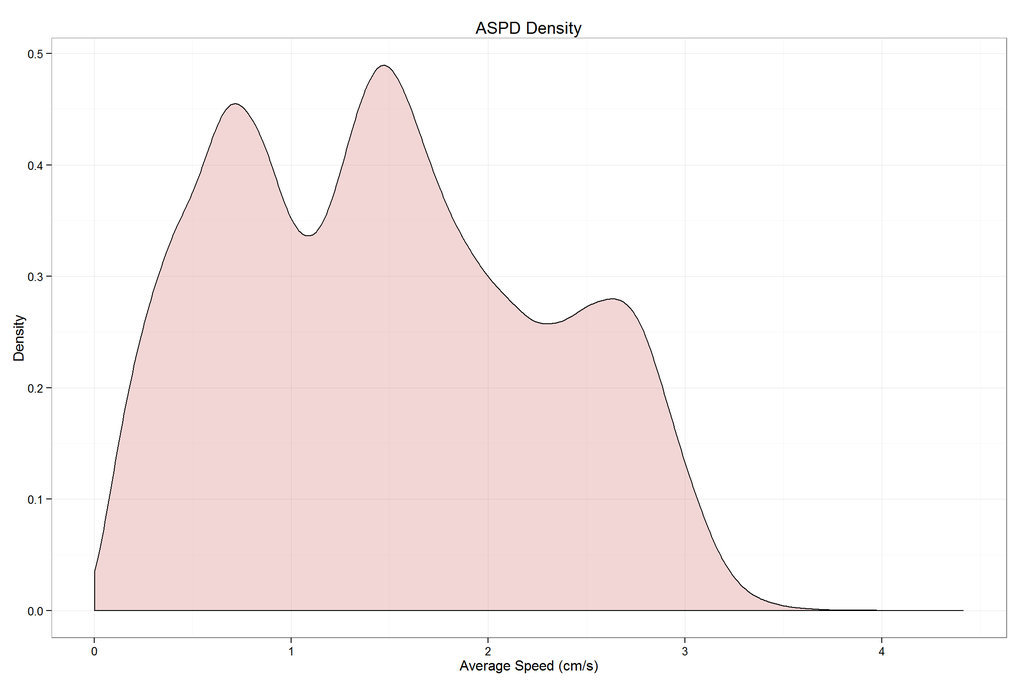

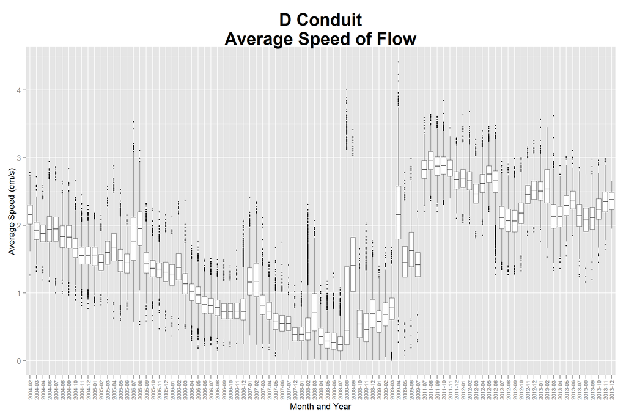

## 4.3 Conductivity

### 4.3.1 Excluded Values

No values have been excluded from the following summaries

### 4.3.2 Statistical Summary

| Min. | 1st Qu. | Median | Mean | 3rd Qu. | Max. |
| --- | --- | --- | --- | --- | --- |
| 0.263 | 0.283 | 0.287 | 0.2874 | 0.292 | 0.489 |

### 4.3.3 COND Plots

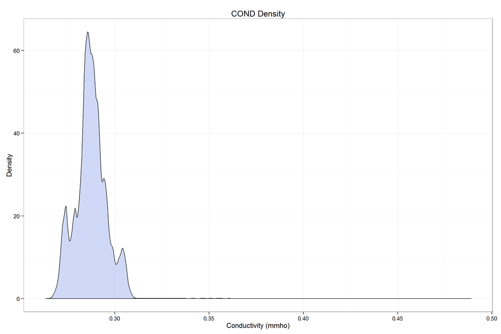

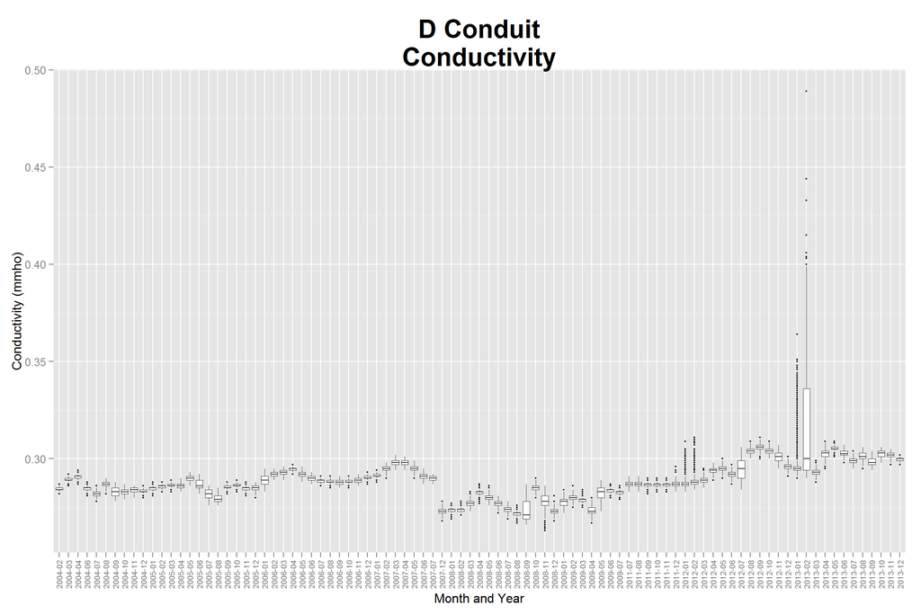

## 4.4 Temperature

All of the Falmouth 2D-ACM temperature sensors show a marked decline in temperature readings over time caused by the temperature transducer in the unit failing. No temperature values from the any Falmouth 2D-ACM should be trusted or used for analysis without rigorous quality checks and comparisons to other data sources that are known to be valid.

### 4.4.1 Excluded Values

No values have been excluded from the set of temperature values.

### 4.4.2 Statistical Summary

| Min. | 1st Qu. | Median | Mean | 3rd Qu. | Max. |
| --- | --- | --- | --- | --- | --- |
| 20.49 | 20.73 | 20.76 | 20.74 | 20.78 | 20.83 |

### 4.4.3 TEMP Plots

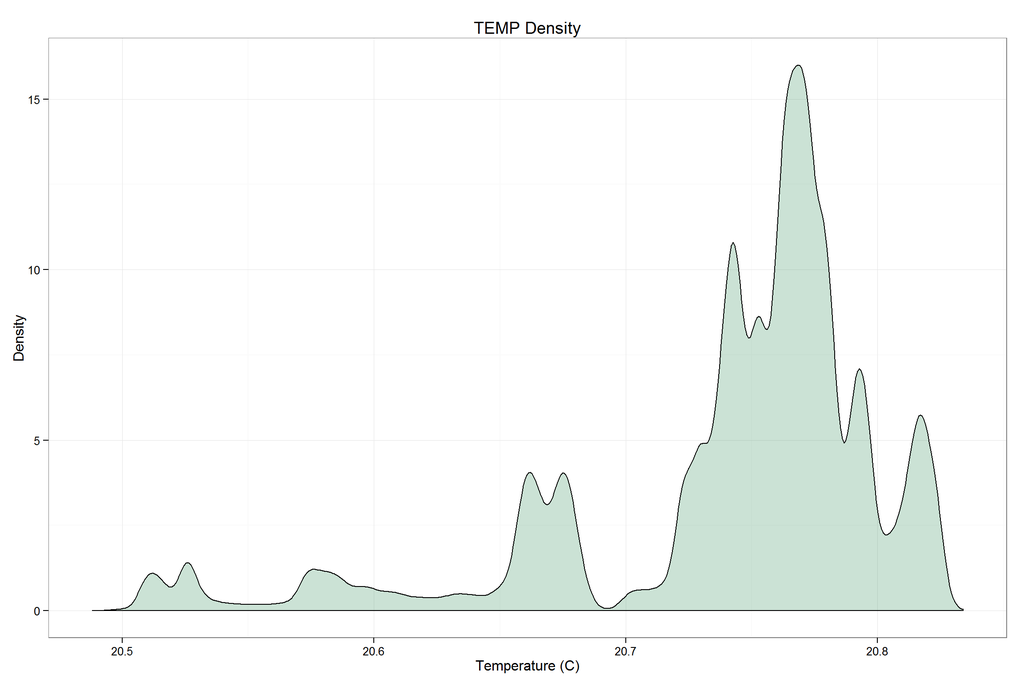

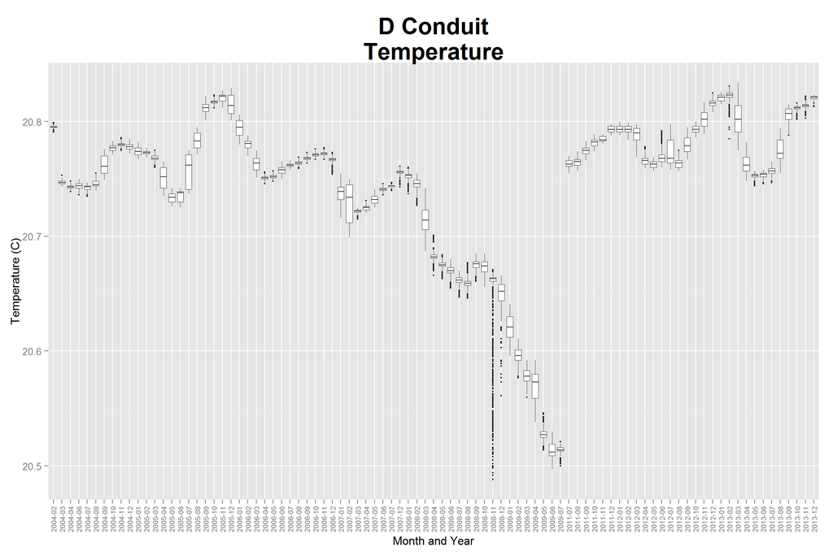

## 4.5 Pressure

All of the Falmouth 2D-ACM pressure sensors show a marked decline in pressure readings over time caused by the pressure transducer in the unit failing. No pressure values from the any Falmouth 2D-ACM should be trusted or used for analysis without rigorous quality checks and comparisons to other data sources that are known to be valid.

### 4.5.1 Excluded Values

No pressure readings have been excluded from the following analysis.

### 4.5.2 Statistical Summary

| Min. | 1st Qu. | Median | Mean | 3rd Qu. | Max. |
| --- | --- | --- | --- | --- | --- |
| 85.96 | 87 | 87.2 | 87.13 | 87.3 | 88.78 |

### 4.5.3 PRES Plots

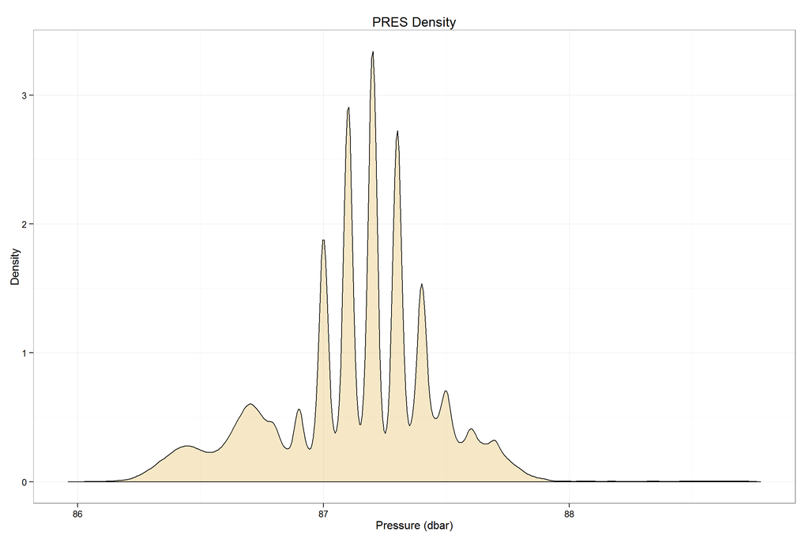

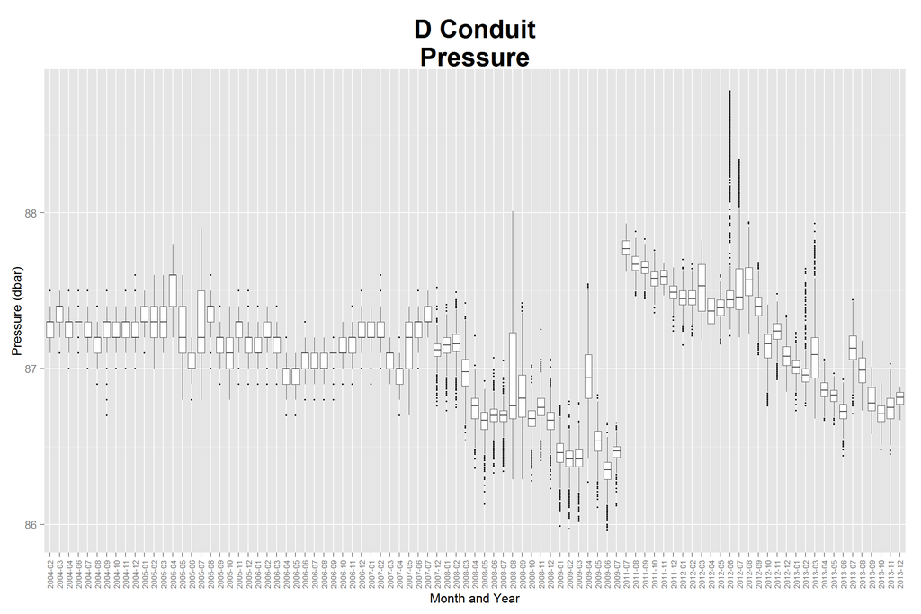

## 4.6 Average Direction

Note that average direction values must be handled differently due to the topological differences in the structure of the underlying data. Directional data lies on a circle, not on a number line, so any and all statistical analyses must take this into account.

### 4.6.1 Excluded Values

### 4.6.2 Statistical Summary

| Min. | 1st Qu. | Median | Mean | 3rd Qu. | Max. |
| --- | --- | --- | --- | --- | --- |
| 0.013 | 40.14 | 70.51 | 76.77 | 96.45 | 360 |

### 4.6.3 AVDIR Plots

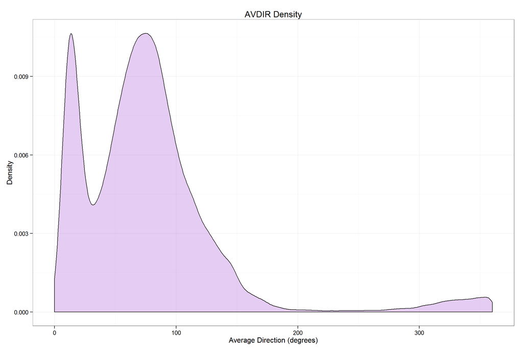

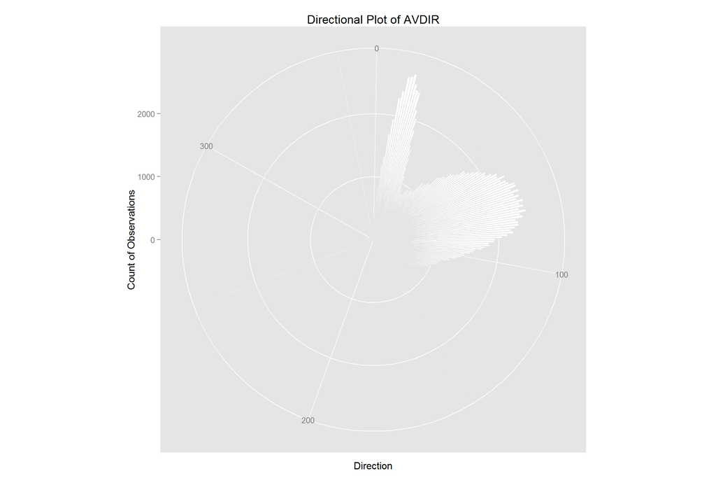